# Size: L1 vs L2

## Data Analysis

[output not shown]

After removal of entries with missing data due to “No answers”, we have 134 subjects in total and 1629 observations left. The subjects are distributed as follows:

```
# A tibble: 8 x 3
# Groups:   LangLev [?]
  LangLev   List `n_distinct(Subject)`
   <fctr> <fctr>                 <int>
1      A2      0                     8
2      A2      1                     8
3      B1      0                    11
4      B1      1                    22
5     B2+      0                    28
6     B2+      1                    23
7      L1      0                    18
8      L1      1                    16
```

## Model Building

The set up is the same as for the Orientation L1 vs L2 case. See there for details.

Hence, we consider the following model:

```r
lmm<- lmer(log(Time) ~ Type + LangLev + List + LangLev:Type + (1 | List:Subject)+ (1 | List:Type:Trial), data = DLM, REML=FALSE)
```

## Likelihood Ratio Tests

For the random factors:

```r
lm.0 <- lm(log(Time) ~ 1, data = DLM)
# LeaYrs AECI AMGE
lmm.0 <- lmer(log(Time) ~ (1 | List:Subject)+ (1 | List:Subject:Trial), data = DLM)
AIC(lm.0,lmm.0)
```

```
      df  AIC
lm.0   2 2418
lmm.0  4 1998
```

```r
lmm.4 <- update(lmm,.~.-(1 | List:Subject))
anova(lmm.4,lmm)
```

```
Data: DLM
Models:
lmm.4: log(Time) ~ Type + LangLev + List + (1 | List:Type:Trial) + Type:LangLev
lmm: log(Time) ~ Type + LangLev + List + LangLev:Type + (1 | List:Subject) +
lmm:     (1 | List:Type:Trial)
      Df  AIC  BIC logLik deviance Chisq Chi Df Pr(>Chisq)
lmm.4 11 2216 2275  -1097     2194
lmm   12 1771 1836   -874     1747   446      1     <2e-16 ***
---
Signif. codes:  0 '***' 0.001 '**' 0.01 '*' 0.05 '.' 0.1 ' ' 1
```

```r
lmm.5 <- update(lmm,.~.-(1 | List:Type:Trial))
anova(lmm.5,lmm)
```

```
Data: DLM
Models:
lmm.5: log(Time) ~ Type + LangLev + List + (1 | List:Subject) + Type:LangLev
lmm: log(Time) ~ Type + LangLev + List + LangLev:Type + (1 | List:Subject) +
lmm:     (1 | List:Type:Trial)
      Df  AIC  BIC logLik deviance Chisq Chi Df Pr(>Chisq)
lmm.5 11 1935 1995   -957     1913
lmm   12 1771 1836   -874     1747   166      1     <2e-16 ***
---
Signif. codes:  0 '***' 0.001 '**' 0.01 '*' 0.05 '.' 0.1 ' ' 1
```

and for the fixed factors:

```r
# lmm.0 <- lmer(log(Time) ~ (1 | List:Subject)+ (1 | List:Type:Trial), data = DLM)
lmm.1 <- update(lmm, .~. - List)
anova(lmm.1,lmm)
```

```
Data: DLM
Models:
lmm.1: log(Time) ~ Type + LangLev + (1 | List:Subject) + (1 | List:Type:Trial) +
lmm.1:     Type:LangLev
lmm: log(Time) ~ Type + LangLev + List + LangLev:Type + (1 | List:Subject) +
lmm:     (1 | List:Type:Trial)
      Df  AIC  BIC logLik deviance Chisq Chi Df Pr(>Chisq)
lmm.1 11 1771 1830   -874     1749
lmm   12 1771 1836   -874     1747  1.21      1       0.27
```

```r
lmm.2 <- update(lmm, .~. - Type - LangLev:Type)
anova(lmm.2,lmm)
```

```
Data: DLM
Models:
lmm.2: log(Time) ~ LangLev + List + (1 | List:Subject) + (1 | List:Type:Trial)
lmm: log(Time) ~ Type + LangLev + List + LangLev:Type + (1 | List:Subject) +
lmm:     (1 | List:Type:Trial)
      Df  AIC  BIC logLik deviance Chisq Chi Df Pr(>Chisq)
lmm.2  8 1775 1818   -879     1759
lmm   12 1771 1836   -874     1747  11.3      4      0.023 *
---
Signif. codes:  0 '***' 0.001 '**' 0.01 '*' 0.05 '.' 0.1 ' ' 1
```

```r
lmm.3 <- update(lmm, .~. - LangLev - LangLev:Type)
anova(lmm.3,lmm)
```

```
Data: DLM
Models:
lmm.3: log(Time) ~ Type + List + (1 | List:Subject) + (1 | List:Type:Trial)
lmm: log(Time) ~ Type + LangLev + List + LangLev:Type + (1 | List:Subject) +
lmm:     (1 | List:Type:Trial)
      Df  AIC  BIC logLik deviance Chisq Chi Df Pr(>Chisq)
lmm.3  6 1787 1819   -887     1775
lmm   12 1771 1836   -874     1747  27.4      6    0.00012 ***
---
Signif. codes:  0 '***' 0.001 '**' 0.01 '*' 0.05 '.' 0.1 ' ' 1
```

```r
lmm.4 <- update(lmm, .~. - LangLev:Type)
anova(lmm.4,lmm)
```

```
Data: DLM
Models:
lmm.4: log(Time) ~ Type + LangLev + List + (1 | List:Subject) + (1 |
lmm.4:     List:Type:Trial)
lmm: log(Time) ~ Type + LangLev + List + LangLev:Type + (1 | List:Subject) +
lmm:     (1 | List:Type:Trial)
      Df  AIC  BIC logLik deviance Chisq Chi Df Pr(>Chisq)
lmm.4  9 1772 1821   -877     1754
lmm   12 1771 1836   -874     1747  6.82      3      0.078 .
---
Signif. codes:  0 '***' 0.001 '**' 0.01 '*' 0.05 '.' 0.1 ' ' 1
```

We see that `Type` and `LangLev` are significant.

## Analysis of Variance

We present here the Anova of type III with Satterwhite approximation. Again we refer to the Orientation L1 vs L2 case for more details.

```r
require(lmerTest)
lmm<- lmer(log(Time) ~ Type + LangLev + List + LangLev:Type + (1 | List:Subject)+ (1 | List:Type:Trial), data = DLM, REML=FALSE)
anova(lmm,type=3)
```

```
Analysis of Variance Table of type III  with  Satterthwaite
approximation for degrees of freedom
             Sum Sq Mean Sq NumDF DenDF F.value  Pr(>F)
Type          0.587   0.587     1    34    4.23 0.04750 *
LangLev       3.011   1.004     3   134    7.23 0.00016 ***
List          0.169   0.169     1    87    1.22 0.27296
Type:LangLev  0.949   0.316     3  1483    2.28 0.07771 .
---
Signif. codes:  0 '***' 0.001 '**' 0.01 '*' 0.05 '.' 0.1 ' ' 1
```

and the effects with t test:

```r
summary(lmm, transform="log")
```

```
Linear mixed model fit by maximum likelihood t-tests use Satterthwaite approximations to degrees
  of freedom [lmerMod]
Formula: log(Time) ~ Type + LangLev + List + LangLev:Type + (1 | List:Subject) +
    (1 | List:Type:Trial)
   Data: DLM

     AIC      BIC   logLik deviance df.resid
    1771     1836     -874     1747     1617

Scaled residuals:
   Min     1Q Median     3Q    Max
-3.516 -0.663 -0.082  0.583  4.543

Random effects:
 Groups          Name        Variance Std.Dev.
 List:Subject    (Intercept) 0.0796   0.282
 List:Type:Trial (Intercept) 0.0213   0.146
 Residual                    0.1388   0.373
Number of obs: 1629, groups:  List:Subject, 134; List:Type:Trial, 32

Fixed effects:
                         Estimate Std. Error        df t value Pr(>|t|)
(Intercept)                6.9155     0.0970  185.0000   71.30   <2e-16 ***
TypeMISMATCH               0.1289     0.0771  121.0000    1.67   0.0972 .
LangLevB1                  0.0246     0.0996  176.0000    0.25   0.8053
LangLevB2+                -0.0678     0.0932  176.0000   -0.73   0.4676
LangLevL1                 -0.3225     0.0982  173.0000   -3.28   0.0012 **
List1                      0.0819     0.0742   87.0000    1.10   0.2730
TypeMISMATCH:LangLevB1    -0.1001     0.0702 1484.0000   -1.43   0.1540
TypeMISMATCH:LangLevB2+    0.0250     0.0648 1478.0000    0.39   0.7003
TypeMISMATCH:LangLevL1     0.0188     0.0672 1476.0000    0.28   0.7793
---
Signif. codes:  0 '***' 0.001 '**' 0.01 '*' 0.05 '.' 0.1 ' ' 1

Correlation of Fixed Effects:
               (Intr) TyMISMATCH LngLB1 LnLB2+ LngLL1 List1  TMISMATCH:LLB1 TMISMATCH:LLB2
TypMISMATCH    -0.408
LangLevB1      -0.671  0.224
LangLevB2+     -0.749  0.238      0.723
LangLevL1      -0.709  0.227      0.687  0.735
List1          -0.379  0.001     -0.067  0.015  0.008
TMISMATCH:LLB1  0.255 -0.605     -0.343 -0.262 -0.249 -0.005
TMISMATCH:LLB2  0.271 -0.653     -0.265 -0.349 -0.269  0.004  0.716
TMISMATCH:LLL   0.263 -0.631     -0.256 -0.274 -0.347  0.001  0.693          0.750
```

We seek confirmation of results by Bootstrap confidence intervals

```r
#confint(lmm,method="Wald")
confint(lmm,method="boot")
```

```
                          2.5 %  97.5 %
.sig01                   0.2381  0.3133
.sig02                   0.1008  0.1800
.sigma                   0.3599  0.3873
(Intercept)              6.7010  7.1094
TypeMISMATCH            -0.0245  0.2918
LangLevB1               -0.1805  0.2452
LangLevB2+              -0.2490  0.1169
LangLevL1               -0.5148 -0.1245
List1                   -0.0842  0.2290
TypeMISMATCH:LangLevB1  -0.2300  0.0446
TypeMISMATCH:LangLevB2+ -0.0960  0.1597
TypeMISMATCH:LangLevL1  -0.1034  0.1559
```

We also include the analysis via `merTools` package that calculates simulated values of the (fixed and random) effects from the posterior using the function `arm::sim`:

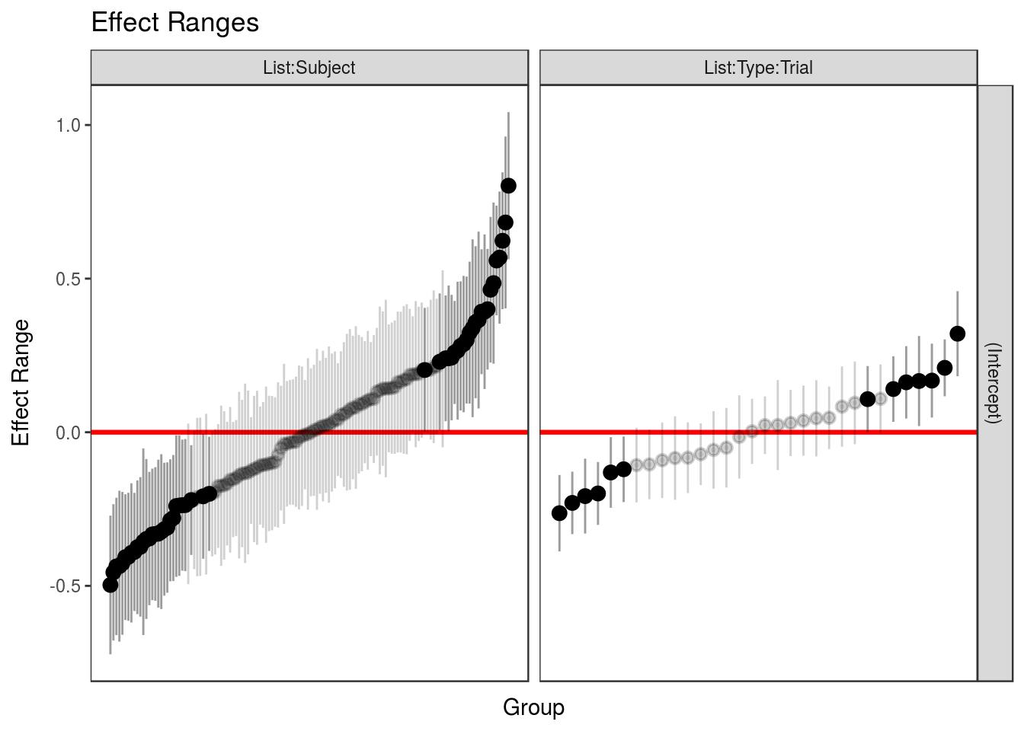

```r
detach("package:lmerTest",unload=TRUE)
require(merTools)
lmm <- lmer(formula = log(Time) ~ LangLev + Type + List + LangLev:Type + (1 | List:Subject) +
     (1 | List:Type:Trial), data = DLM, REML = FALSE)
plotREsim(REsim(lmm, n.sims= 100), level=0.95, stat="mean")
```

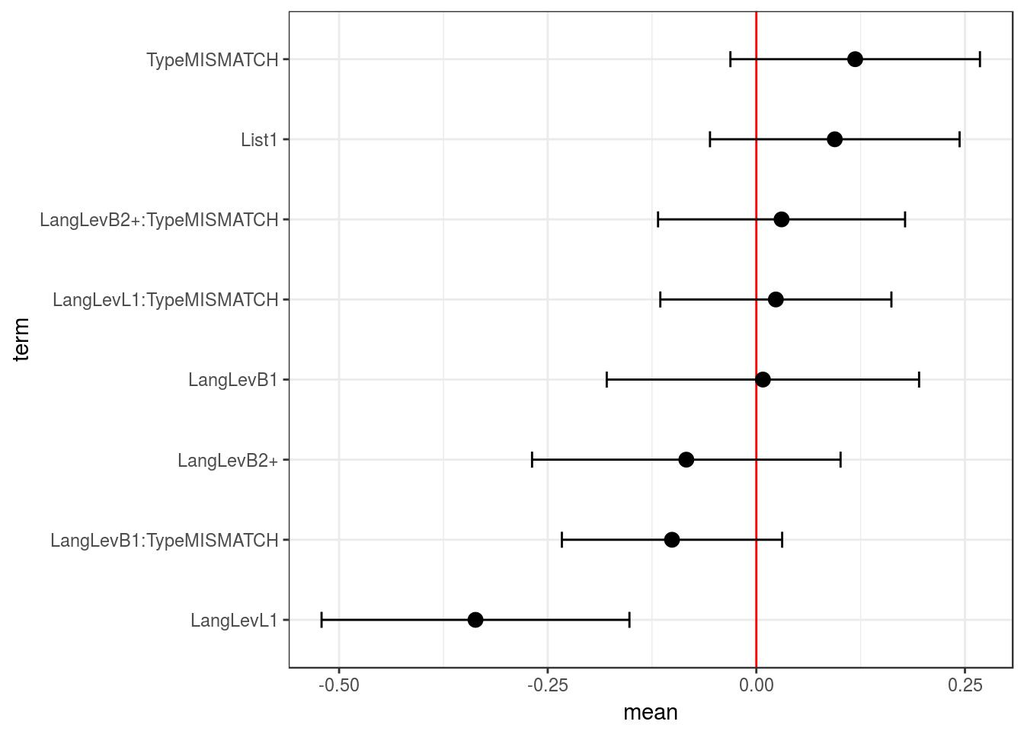

```r
plotFEsim(FEsim(lmm, n.sims = 100), level = 0.95, stat = 'mean', intercept = FALSE)
```

## Conclusions

We plot the random and the fixed effects together with their 95% confidence levels in the figure. The confidence levels are obtained by the estimated standard deviation and the normal distribution. However, other analysis with boostrapped confidence intervals confirmed the same conclusions. For the fixed effects we tranform back the measurments in the original linear scale of milliseconds.

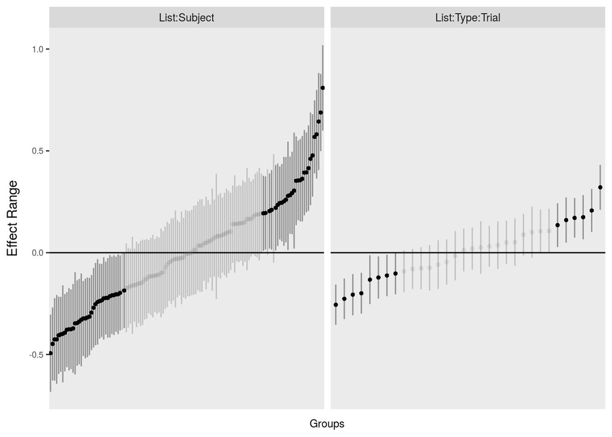

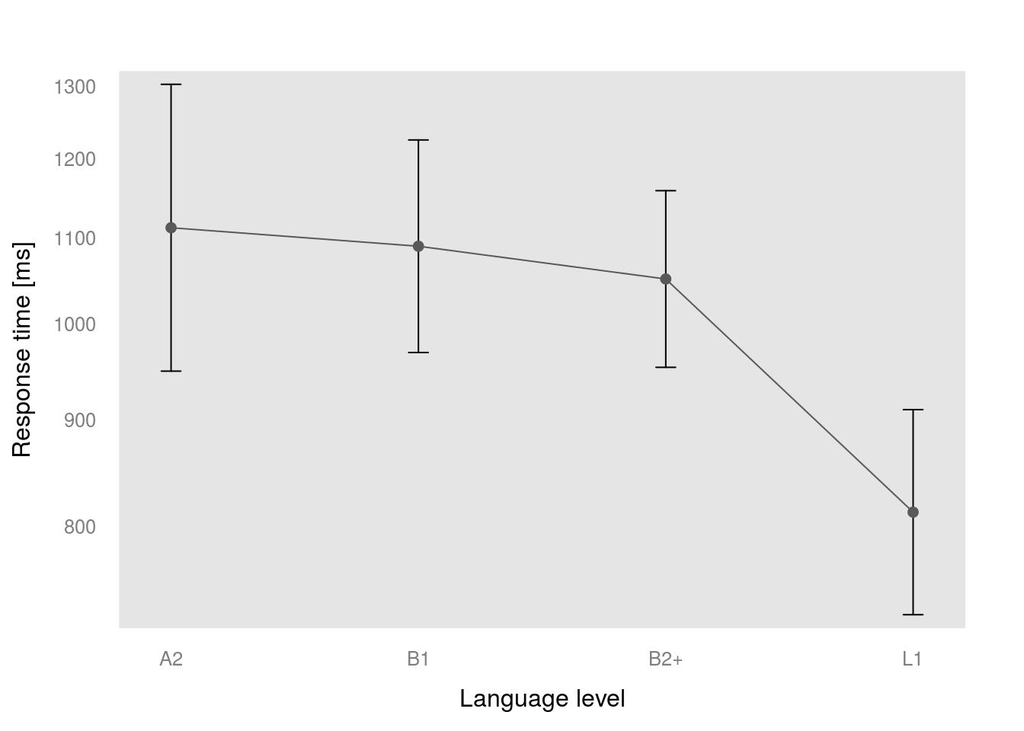

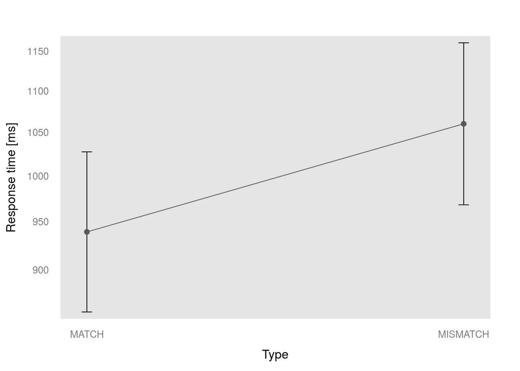

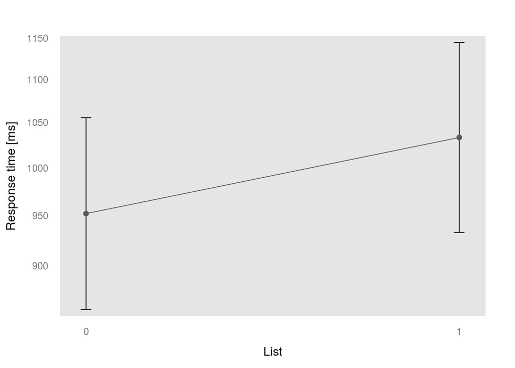

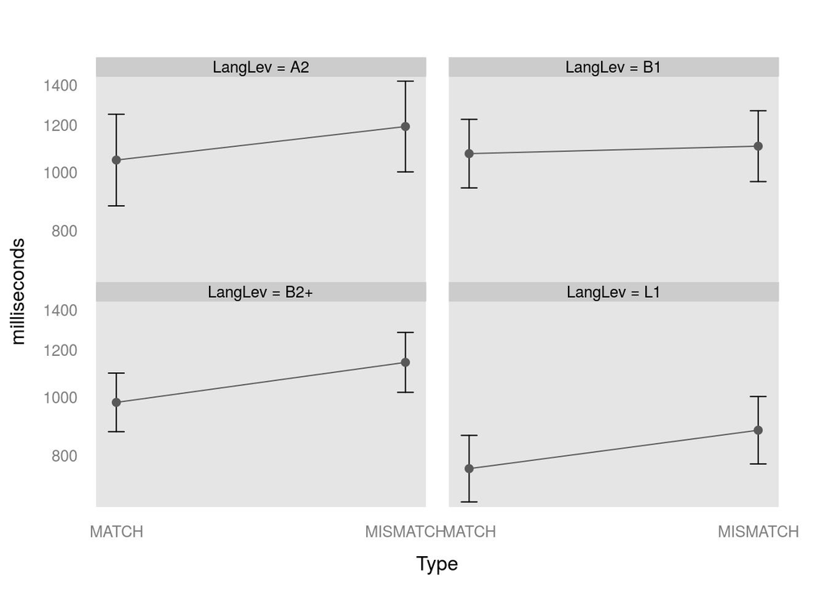

## Diagnostic plots

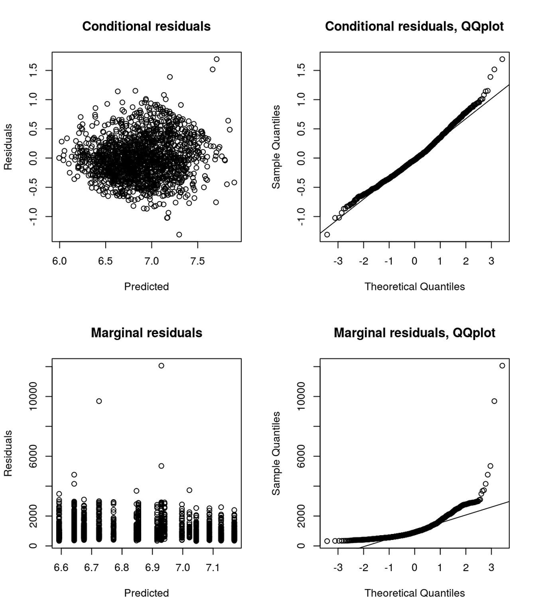

```r
#lmm<- glmer(Time ~ LangLev + Type + (1 | Subject)+ (1 | Type:List:Type:Trial), data = DLM,family=Gamma(link = "identity"))
par(mfrow=c(2,2))
# plot(lm4,which=1:4)

plot(fitted(lmm, Type = "response"), residuals(lmm, Type = "response"),
     main = "Conditional residuals", xlab = "Predicted", ylab = "Residuals")

res <- residuals(lmm, Type = "response")
qqnorm(res, main = "Conditional residuals, QQplot")
qqline(res)

lm.0 <- lm(log(Time) ~ Type + LangLev + List + LangLev:Type, data = DLM)
x <- model.matrix(lm.0)
pred <- x %*% fixef(lmm)
res <- DLM$Time - pred
plot(pred, res, main = "Marginal residuals", xlab = "Predicted", ylab = "Residuals")
qqnorm(res, main = "Marginal residuals, QQplot")
qqline(res)
```

The joint qqplot looks normal. The marginal look less compliant with the normality assumptions.